# Project-Ensemble Techniques - Term Deposit Subscription Prediction_06.19.2020

### 3.2.3 Boosting

#### 3.2.3.1. AdaBoost Classifier

```python
# train the adaboosting model on the train data

abcl = AdaBoostClassifier(n_estimators=100, learning_rate=0.1, random_state=22)
abcl = abcl.fit(x2_train,y2_train)
```

```python
# predict the independent variable

predict_abcl = abcl.predict(x2_test)
```

#### 1. Confusion Matrix for AdaBoost Classifier Model

```python
# print confusion matrix

cm = metrics.confusion_matrix(y2_test,predict_abcl)
print(cm)
```

```
[[11836   177]
 [ 1290   261]]
```

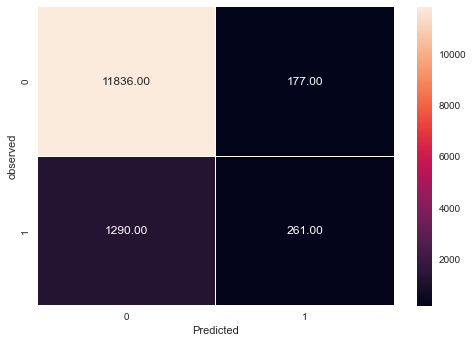

```python
# plot the confusion matrix in terms of heatmap for better visualization.
# pass parameters in draw_cm function to plot the heatmap.

draw_cm(y2_test,predict_abcl)
```

```python
# True Positive (TP) = 261
# True Negative (TN) = 11836
# False Positive (FP) = 177
# False Negative(FN) = 1290
```

#### 2. Metrics for AdaBoost Classifier Model

```python
# compare score between train and test data

print('Training Score:',abcl.score(x2_train,y2_train))
print('')
print('Testing Score:',abcl.score(x2_test,y2_test))
```

```
Training Score: 0.8915853003444244

Testing Score: 0.8918460631082277
```

```python
# adaboost classifier metrics

abcl_accuracy = accuracy_score(y2_test, predict_abcl)
abcl_recall = recall_score(y2_test, predict_abcl)
abcl_f1 = f1_score(y2_test,predict_abcl)
abcl_precision = precision_score(y2_test,predict_abcl)
abcl_AUC = roc_auc_score(y2_test,predict_abcl)

print('Accuracy:', abcl_accuracy )
print()
print('Recall:', abcl_recall )
print()
print('F1 Score:', abcl_f1)
print()
print('Precision:', abcl_precision)
print()
print('AUC:', abcl_AUC)
```

```
Accuracy: 0.8918460631082277

Recall: 0.16827852998065765

F1 Score: 0.26244343891402716

Precision: 0.5958904109589042

AUC: 0.5767722459276468
```

```python
# saving the metrics for adaboost classifier in a dataframe

dfAdaBoost = pd.DataFrame({'Model':['AdaBoost Classifier'],'Accuracy':abcl_accuracy,
                           'Recall':abcl_recall,'F1 Score':abcl_f1,
                           'Precision':abcl_precision,'AUC':abcl_AUC})

dfAdaBoost.head()
```

|  | Model | Accuracy | Recall | F1 Score | Precision | AUC |
| --- | --- | --- | --- | --- | --- | --- |
| 0 | AdaBoost Classifier | 0.891846 | 0.168279 | 0.262443 | 0.59589 | 0.576772 |

```python
# concatenate the dataframe of adaboost classifier model with the earlier dataframe

dfModelComparison = pd.concat([dfModelComparison,dfAdaBoost])

dfModelComparison
```

|  | Model | Accuracy | Recall | F1 Score | Precision | AUC |
| --- | --- | --- | --- | --- | --- | --- |
| 0 | Base Logistic Regression | 0.898039 | 0.284333 | 0.389404 | 0.617647 | 0.630804 |
| 0 | Tuned Logistic Regression | 0.818564 | 0.744036 | 0.483959 | 0.358608 | 0.786111 |
| 0 | Decision Tree | 0.862725 | 0.464861 | 0.436441 | 0.411295 | 0.689477 |
| 0 | Pruned Decision Tree | 0.897523 | 0.243714 | 0.352283 | 0.635294 | 0.612825 |
| 0 | Bagging Classifier | 0.894500 | 0.419729 | 0.476400 | 0.550761 | 0.687764 |
| 0 | Random Forest | 0.894058 | 0.410703 | 0.469937 | 0.549138 | 0.683583 |
| 0 | AdaBoost Classifier | 0.891846 | 0.168279 | 0.262443 | 0.595890 | 0.576772 |

#### 3. Visualization of Metrics for AdaBoost Classifier Model

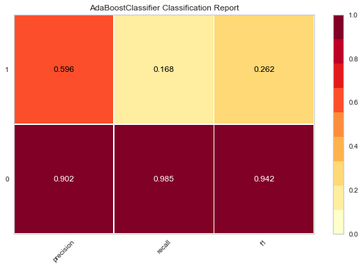

```python
# visualizing the scores of adaboost classifier model via yellowbricks

viz = ClassificationReport(abcl)
viz.fit(x2_train,y2_train)
viz.score(x2_test,y2_test)
viz.show();
```

1. The visualization shows that the precision is about 59%
2. Recall is about 16%
3. Number of total people subscribing to Term Deposit is 1551
4. Number of people subscribing to the Term Deposit successfully predicted by model is 261
5. Number of people subscribing to the Term Deposit not predicted by the model is 1290 </font>

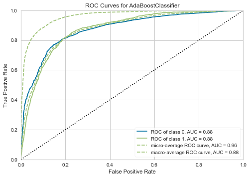

```python
# plotting area under the AUC curve

roc = ROCAUC(abcl)
roc.fit(x2_train,y2_train)
roc.score(x2_test,y2_test)
roc.show();
```

#### 3.2.3.2. GradientBoost Classifier

```python
# modeling and training the gradientboost classfier

gbcl = GradientBoostingClassifier(n_estimators = 100,random_state=1)
gbcl = gbcl.fit(x2_train, y2_train)
```

```python
# predict the independent variable

predict_gbcl = gbcl.predict(x2_test)
```

#### 1. Confusion Matrix for GradientBoost Classifier Model

```python
# print confusion matrix

cm = metrics.confusion_matrix(y2_test,predict_gbcl)
print(cm)
```

```
[[11691   322]
 [ 1032   519]]
```

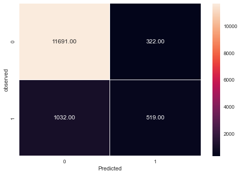

```python
# plot the confusion matrix in terms of heatmap for better visualization.
# pass parameters in draw_cm function to plot the heatmap.

draw_cm(y2_test,predict_gbcl)
```

```python
# True Positive (TP) = 519
# True Negative (TN) = 11691
# False Positive (FP) = 322
# False Negative(FN) = 1032
```

#### 2. Metrics for GradientBoost Classifier Model

```python
# compare score between train and test data for gradientboost classifier model

print('Training Score:',gbcl.score(x2_train,y2_train))
print('')
print('Testing Score:',gbcl.score(x2_test,y2_test))
```

```
Training Score: 0.9032135747464215

Testing Score: 0.9001769389560602
```

```python
# gradientboost classifier metrics

gbcl_accuracy = accuracy_score(y2_test, predict_gbcl)
gbcl_recall = recall_score(y2_test, predict_gbcl)
gbcl_f1 = f1_score(y2_test,predict_gbcl)
gbcl_precision = precision_score(y2_test,predict_gbcl)
gbcl_AUC = roc_auc_score(y2_test,predict_gbcl)

print('Accuracy:', gbcl_accuracy )
print()
print('Recall:', gbcl_recall )
print()
print('F1 Score:', gbcl_f1)
print()
print('Precision:', gbcl_precision)
print()
print('AUC:', gbcl_AUC)
```

```
Accuracy: 0.9001769389560602

Recall: 0.3346228239845261

F1 Score: 0.43394648829431437

Precision: 0.6171224732461356

AUC: 0.6539092643189093
```

```python
# saving the metrics for gradientboost classifier in a dataframe

dfGradientBoost = pd.DataFrame({'Model':['GradientBoost Classifier'],'Accuracy':gbcl_accuracy,
                           'Recall':gbcl_recall,'F1 Score':gbcl_f1,
                           'Precision':gbcl_precision,'AUC':gbcl_AUC})

dfGradientBoost.head()
```

|  | Model | Accuracy | Recall | F1 Score | Precision | AUC |
| --- | --- | --- | --- | --- | --- | --- |
| 0 | GradientBoost Classifier | 0.900177 | 0.334623 | 0.433946 | 0.617122 | 0.653909 |

```python
# concatenate the dataframe of gradientboost classifier model with the earlier dataframe

dfModelComparison = pd.concat([dfModelComparison,dfGradientBoost])

dfModelComparison
```

|  | Model | Accuracy | Recall | F1 Score | Precision | AUC |
| --- | --- | --- | --- | --- | --- | --- |
| 0 | Base Logistic Regression | 0.898039 | 0.284333 | 0.389404 | 0.617647 | 0.630804 |
| 0 | Tuned Logistic Regression | 0.818564 | 0.744036 | 0.483959 | 0.358608 | 0.786111 |
| 0 | Decision Tree | 0.862725 | 0.464861 | 0.436441 | 0.411295 | 0.689477 |
| 0 | Pruned Decision Tree | 0.897523 | 0.243714 | 0.352283 | 0.635294 | 0.612825 |
| 0 | Bagging Classifier | 0.894500 | 0.419729 | 0.476400 | 0.550761 | 0.687764 |
| 0 | Random Forest | 0.894058 | 0.410703 | 0.469937 | 0.549138 | 0.683583 |
| 0 | AdaBoost Classifier | 0.891846 | 0.168279 | 0.262443 | 0.595890 | 0.576772 |
| 0 | GradientBoost Classifier | 0.900177 | 0.334623 | 0.433946 | 0.617122 | 0.653909 |

#### 3. Visualization of Metrics for GradientBoost Classifier Model

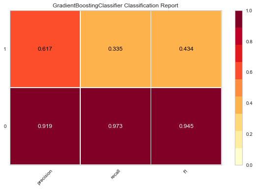

```python
# visualizing the scores via yellowbricks

viz = ClassificationReport(gbcl)
viz.fit(x2_train,y2_train)
viz.score(x2_test,y2_test)
viz.show();
```

1. The visualization shows that the precision is about 61%
2. Recall is about 33%
3. Number of total people subscribing to Term Deposit is 1551
4. Number of people subscribing to the Term Deposit successfully predicted by model is 519
5. Number of people subscribing to the Term Deposit not predicted by the model is 1032 </font>

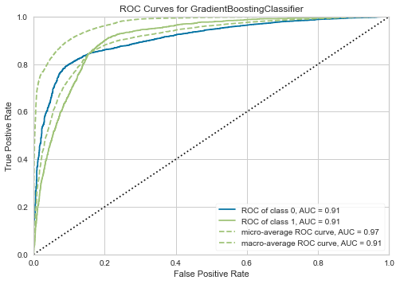

```python
# plotting area under the AUC curve

roc = ROCAUC(gbcl)
roc.fit(x2_train,y2_train)
roc.score(x2_test,y2_test)
roc.show();
```

#### 3.3. Make a DataFrame to compare models and their metrics. Give conclusion regarding the best algorithm and your reason behind it. (5 marks)

### 3.3.1 Machine Learning Model Comparison

```python
# final dataframe with performance metrics for all models created

dfModelComparison
```

|  | Model | Accuracy | Recall | F1 Score | Precision | AUC |
| --- | --- | --- | --- | --- | --- | --- |
| 0 | Base Logistic Regression | 0.898039 | 0.284333 | 0.389404 | 0.617647 | 0.630804 |
| 0 | Tuned Logistic Regression | 0.818564 | 0.744036 | 0.483959 | 0.358608 | 0.786111 |
| 0 | Decision Tree | 0.862725 | 0.464861 | 0.436441 | 0.411295 | 0.689477 |
| 0 | Pruned Decision Tree | 0.897523 | 0.243714 | 0.352283 | 0.635294 | 0.612825 |
| 0 | Bagging Classifier | 0.894500 | 0.419729 | 0.476400 | 0.550761 | 0.687764 |
| 0 | Random Forest | 0.894058 | 0.410703 | 0.469937 | 0.549138 | 0.683583 |
| 0 | AdaBoost Classifier | 0.891846 | 0.168279 | 0.262443 | 0.595890 | 0.576772 |
| 0 | GradientBoost Classifier | 0.900177 | 0.334623 | 0.433946 | 0.617122 | 0.653909 |

```python
# marketing team is trying to increase the hit ratio of the subscribers of Term Deposit
# true negative (TN) should be low and Recall should be high

dfModelComparison['Recall'].max()
```

```
0.7440361057382334
```

### 3.3.2 Conclusion regarding the best algorithm

1. The problem statement is to build a model that will help the marketing team to identify potential customers who will subscribe to Term Deposit offered by the bank.
2. This means that the model needs to predit the maximum number of potential subscribers who can be contacted.
3. Which in turn means, that the model should lower the **False negative** (People identified by the model to not subscribe to Term Deposit but who in fact subscribe to the Term Deposit).
4. This implies that the model with the **lowest False Negative** or **highest Recall score** is to be selected as the best prediction model for the problem.
5. From the Model score comparison dataframe, it is evident that the **TUNED LOGISTIC REGRESSION** model has the highest recall and hence the best model to use for the problem statement.
6. The Precision score is the lowest amongst all the models for the Tuned Logistic Regression model, as now the model is predicting to reach out to more people from the dataset.
7. The precision score can be compared to the actual conversion rate for subscribing to Term Deposit with respect to the number of people contacted by the marketing team. But with respect to the overall data the True Positive predicted by the Tuned Logistic regression model is **8.5%** which is the highest of all the models.  
   **NOTE: The performance metrics of the ensemble models may improve upon further tuning and may have better recall score than the Tuned Logisitic Regression Model. The conclusion is drawn from the base ensembel models which haven't been tuned.**